# MA [46]15: Lab activity 2

Hongyi Yu

AAA

# Introduction

In this lab activity we are going to analyze the `babynames` dataset.

**`[==[`** After loading the `babynames` package below, read the help for the `babynames` dataset and provide a short sentence describing it. **`]==]`**

We start by loading packages, including the `babynames` package containing the data:

```r
library(tidyverse)
library(babynames) # install it with `install.packages("babynames")`
babynames
```

```
## # A tibble: 1,924,665 × 5
##     year sex   name          n   prop
##    <dbl> <chr> <chr>     <int>  <dbl>
##  1  1880 F     Mary       7065 0.0724
##  2  1880 F     Anna       2604 0.0267
##  3  1880 F     Emma       2003 0.0205
##  4  1880 F     Elizabeth  1939 0.0199
##  5  1880 F     Minnie     1746 0.0179
##  6  1880 F     Margaret   1578 0.0162
##  7  1880 F     Ida        1472 0.0151
##  8  1880 F     Alice      1414 0.0145
##  9  1880 F     Bertha     1320 0.0135
## 10  1880 F     Sarah      1288 0.0132
## # … with 1,924,655 more rows
```

# Summarizing and visualizing the data

Here are the names that were most popular in the whole record for both boys and girls:

```r
babynames %>% group_by(sex, name) %>% summarize(total = sum(n)) %>%
  group_by(sex) %>% mutate(rank = min_rank(desc(total))) %>% arrange(rank, sex)
```

[output not shown]

```
## # A tibble: 107,973 × 4
## # Groups:   sex [2]
##    sex   name        total  rank
##    <chr> <chr>       <int> <int>
##  1 F     Mary      4123200     1
##  2 M     James     5150472     1
##  3 F     Elizabeth 1629679     2
##  4 M     John      5115466     2
##  5 F     Patricia  1571692     3
##  6 M     Robert    4814815     3
##  7 F     Jennifer  1466281     4
##  8 M     Michael   4350824     4
##  9 F     Linda     1452249     5
## 10 M     William   4102604     5
## # … with 107,963 more rows
```

For comparison, here are the popular names since 1990, separately for boys and girls:

**`[==[`** Edit the commands below to produce two tables, one for boys and other for girls, with the most popular names since 1990, ordered by number of births. **`]==]`**

```r
babynames %>% filter(sex == "F", year >= 1990) %>% group_by(sex, name) %>% summarize(total = sum(n)) %>% mutate(rank = min_rank(desc(total))) %>% arrange(rank)
```

[output not shown]

```
## # A tibble: 51,183 × 4
## # Groups:   sex [1]
##    sex   name       total  rank
##    <chr> <chr>      <int> <int>
##  1 F     Emily     561299     1
##  2 F     Ashley    467686     2
##  3 F     Jessica   409833     3
##  4 F     Samantha  407773     4
##  5 F     Emma      397978     5
##  6 F     Sarah     388002     6
##  7 F     Elizabeth 383232     7
##  8 F     Olivia    379362     8
##  9 F     Madison   369832     9
## 10 F     Hannah    367423    10
## # … with 51,173 more rows
```

```r
babynames %>% filter(sex == "M", year >= 1990) %>% group_by(sex, name) %>% summarize(total = sum(n)) %>% mutate(rank = min_rank(desc(total))) %>% arrange(rank)
```

[output not shown]

```
## # A tibble: 33,454 × 4
## # Groups:   sex [1]
##    sex   name         total  rank
##    <chr> <chr>        <int> <int>
##  1 M     Michael     835096     1
##  2 M     Jacob       712218     2
##  3 M     Matthew     678528     3
##  4 M     Joshua      652762     4
##  5 M     Christopher 650925     5
##  6 M     Daniel      587569     6
##  7 M     Andrew      565863     7
##  8 M     Joseph      551741     8
##  9 M     William     543294     9
## 10 M     David       530892    10
## # … with 33,444 more rows
```

The following `births.year` dataset summarizes the total number of births per sex across years:

```r
births.year <- babynames %>% group_by(year, sex) %>% summarize(count = sum(n)) %>%
  spread(key = sex, value = count)
```

Here is a plot showing how the number of births varies yearly. The ratio of girls to boys is also plotted in color.

**`[==[`** Modify the command in `births-year-plot` to plot the total number of births per year and color the points using the proportion of girls to boys. **`]==]`**

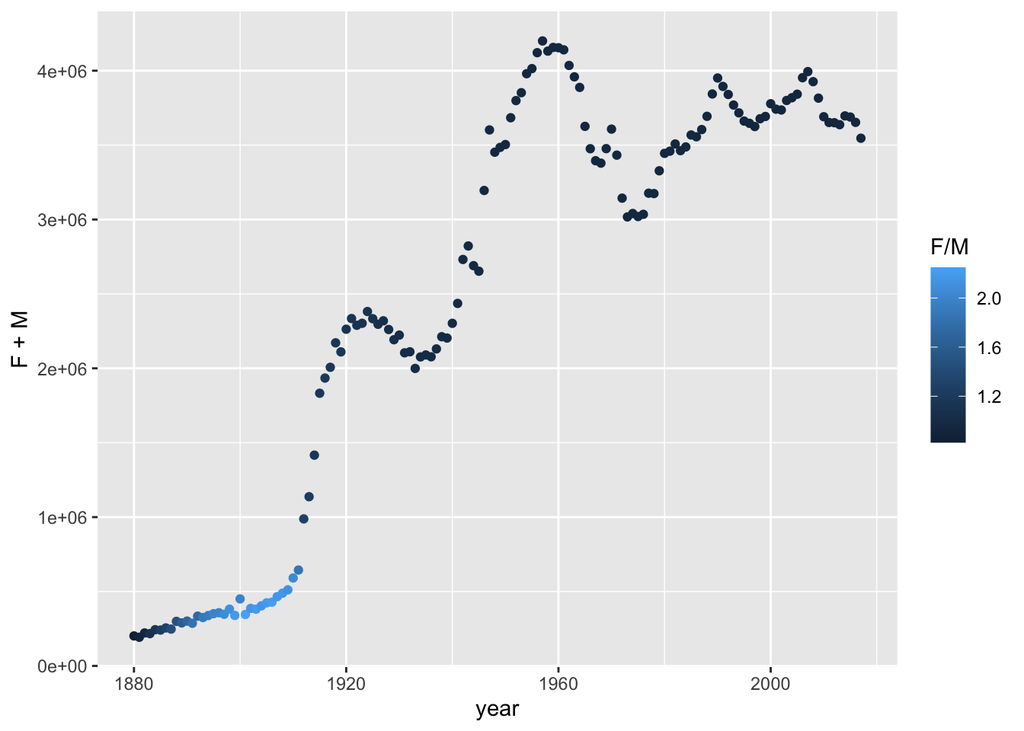

```r
births.year %>% ggplot() + geom_point(aes(x = year, y = F + M, color = F/M))
```

**`[==[`** Open a new Discussion section and summarize your findings in this short analysis. In particular:

- Comment on possible changes to popular names in the last 20 years when compared to the most popular names in the whole record;
- Comment on how the yearly number of births and ratio of girls to boys varies. **`]==]`**

# Discussion

The popular female names in the last 20 years are Emily, Ashley, and Jessica, which are not the most popular names in the whole record. The popular female names in the whole record are Mary, Elizabeth, and Patricia. The popular male names in the last 20 years are Michael, Jacob, and Matthew. Michael is also a popular name in the whole record, but Jacob and Matthew are not popular in the whole record. The popular male names in the whole record are James, John, and Robert. It shows that the popular names in the last 20 years are different from the popular names in the whole record.